# Comprendre les portefeuilles des élus du Congrès — analyse descriptive

*But : **comprendre la donnée et les portefeuilles de chaque membre** — comment ils se comportent, quels patterns se répètent, qui « réussit » et pourquoi, la hype (Pelosi) vs la réalité — **avant** toute stratégie.*

Ce notebook **ne cherche pas d'alpha** : le notebook `05b` a déjà fermé cette question (max $t = 1{,}58$ sur 160 essais, $E[\max t\,|\,H_0] = 2{,}69$, Deflated Sharpe $\approx 0{,}11$). Ici on **décrit** et on **comprend**.

## 0. Charte de lecture

- **Objectif** : comprendre, pas chasser. Aucune section ne peut « promouvoir » un signal — ce droit appartient à un protocole pré-enregistré (une future Partie stratégie).
- **Règles de rigueur** : toute comparaison « X réussit mieux » affiche $n$, un **IC bootstrap**, et un **caveat de multiplicité**. On ne réécrit pas le mot « signal ».
- **Conventions du moteur** (vérifiées à l'audit du 05b) :
  - entrée au **milieu de fourchette** du bracket STOCK Act : $q = \texttt{size\_usd} / P(\tau)$, pas le plafond ;
  - agrégation **toujours par `bioguide_id`** (un même élu porte plusieurs variantes de nom) ;
  - **options absentes** de la table (actions + ETF seulement) — crucial pour lire Pelosi (§6).
- **Périmètre** : `traded` $\in [2013 ; 2026]$ ; 134 464 transactions déclarées $\to$ 118 029 exploitables (tickers avec prix) ; **266 membres** reconstruits, **223 éligibles** ($\ge 10$ trades, $\ge 126$ j).

## 1. Le moteur du 05b, recopié à l'identique

On reconstruit le portefeuille de chaque membre **exactement** comme le 05b (mêmes conventions, mêmes chiffres). Les cellules ci-dessous sont **copiées verbatim** ; la sous-section §1.1 **prouve l'équivalence**.

- **Achat** $\to$ parts, au 1\ier{} jour coté $\ge$ la transaction : $q = \texttt{size\_usd}/P(\tau)$.
- **Vente** $\to$ retire des parts, short interdit : $q^- = \min(\texttt{size\_usd}/P,\ \text{parts détenues})$.
- **Rendement quotidien** *time-weighted* (parts de la veille, apport $\ne$ rendement), winsorisé $\pm 50\%$/j.

```python
# === COPIE EXACTE 05b — cellule 2 (ne pas modifier : garantit l'équivalence) ===
%matplotlib inline
import pandas as pd, numpy as np, glob, os
import matplotlib.pyplot as plt

BASE = "/Users/lemairealice/Downloads/Jupiter/00. S3S4 en cours"
PRICES = os.path.join(BASE, "cache", "prices_v2")
```

```python
# === COPIE EXACTE 05b — cellule 3 (ne pas modifier : garantit l'équivalence) ===
# Table PROPRE canonique S1/S2 (source-primaire) -> noms alignés sur la mécanique du 05.
CLEAN = "/Users/lemairealice/Downloads/Jupiter/00_S1S2_donnees/data/clean/transactions_backtest_2014_2026.csv"
df = pd.read_csv(CLEAN, low_memory=False)
df = (df.drop(columns=["ticker"])
        .rename(columns={"member_name": "name", "ticker_yahoo": "ticker",
                         "direction": "op", "transaction_date": "traded",
                         "amount_midpoint": "size_usd"}))
n0 = len(df)
df["traded"] = pd.to_datetime(df["traded"], errors="coerce")
df = df[df["traded"].dt.year.between(2013, 2026)].reset_index(drop=True)
df = df[["bioguide_id", "name", "ticker", "op", "traded", "size_usd"]]
print(f"{n0} -> {len(df)} trades  |  {df['bioguide_id'].nunique()} membres  |  {df['ticker'].nunique()} tickers")
_n2013 = int((df["traded"].dt.year == 2013).sum())
print(f"dont {_n2013} trades exécutés en 2013 (déclarés dans des dépôts 2014+) — gardés : chaque coupe classe sur tout l'historique ≤ 31/12/Y")
```

```
134464 -> 134429 trades  |  372 membres  |  4618 tickers
dont 743 trades exécutés en 2013 (déclarés dans des dépôts 2014+) — gardés : chaque coupe classe sur tout l'historique ≤ 31/12/Y
```

```python
# === COPIE EXACTE 05b — cellule 5 (ne pas modifier : garantit l'équivalence) ===
# SPY = benchmark ; son index = calendrier maître
spy = (pd.read_csv(os.path.join(PRICES, "SPY.csv"), parse_dates=["Date"])
         .set_index("Date")["close"].sort_index())
cal = spy.index
r_spy = spy.pct_change()          # rendement quotidien du marché
```

```python
# === COPIE EXACTE 05b — cellule 6 (ne pas modifier : garantit l'équivalence) ===
# Télécharge les prix ABSENTS du cache (resumable ; cache complet => 0 => hors-ligne)
import yfinance as yf, time, logging
logging.getLogger("yfinance").setLevel(logging.CRITICAL)
os.makedirs(PRICES, exist_ok=True)
have0  = {os.path.splitext(os.path.basename(p))[0] for p in glob.glob(os.path.join(PRICES, "*.csv"))} - {"failed_v2"}
fail_f = os.path.join(PRICES, "failed_v2.csv")
failed = set(pd.read_csv(fail_f)["ticker"]) if os.path.exists(fail_f) else set()
todo   = [t for t in dict.fromkeys(df["ticker"]) if isinstance(t, str) and t not in have0 and t not in failed]
print(f"cache: {len(have0)} tickers | délistés/échecs connus sautés: {len(set(df['ticker']) & failed)} | à télécharger: {len(todo)}")
new_fail = []
for i in range(0, len(todo), 60):
    chunk = todo[i:i+60]
    try:
        data = yf.download(chunk, start="2012-01-01", end="2026-07-03", auto_adjust=True,
                           progress=False, threads=True, group_by="ticker")
    except Exception as e:
        print("  batch KO:", str(e)[:60]); data = None
    for t in chunk:
        s = None
        try:
            if data is not None and isinstance(data.columns, pd.MultiIndex):
                if t in data.columns.get_level_values(0):
                    s = data[t]["Close"].dropna()
            elif data is not None and "Close" in getattr(data, "columns", []):
                s = data["Close"].dropna()
        except Exception:
            s = None
        if s is None or len(s) < 20:
            new_fail.append(t)
        else:
            s.rename("close").to_csv(os.path.join(PRICES, t + ".csv"))
    time.sleep(0.4)
if new_fail:
    pd.DataFrame({"ticker": new_fail, "classe": "inattendu"}).to_csv(fail_f, mode="a", header=not os.path.exists(fail_f), index=False)
print(f"téléchargés OK: {len(todo) - len(new_fail)} | nouveaux échecs: {len(new_fail)}")
```

```
cache: 3350 tickers | délistés/échecs connus sautés: 1268 | à télécharger: 0
téléchargés OK: 0 | nouveaux échecs: 0
```

```python
# === COPIE EXACTE 05b — cellule 7 (ne pas modifier : garantit l'équivalence) ===
# Charge les prix utiles, alignés sur le calendrier ; garde-fou anti-corruption Yahoo
have = {os.path.splitext(os.path.basename(p))[0] for p in glob.glob(os.path.join(PRICES, "*.csv"))} - {"failed_v2"}
need = sorted(set(df["ticker"]) & have)
missing = sorted(set(df["ticker"]) - have)
prices = {}
for tk in need:
    s = (pd.read_csv(os.path.join(PRICES, tk + ".csv"), parse_dates=["Date"])
           .set_index("Date")["close"].sort_index())
    prices[tk] = s.reindex(cal).ffill()
corrompus = [tk for tk in need if (len(prices[tk].dropna()) < 2
             or prices[tk].dropna().min() < 0.10
             or prices[tk].dropna().pct_change().abs().max() > 3.0)]   # <0,10$ ou saut >300%/j
for tk in corrompus:
    del prices[tk]
need = [tk for tk in need if tk not in set(corrompus)]
n_drop = df[~df["ticker"].isin(need)].shape[0]
df = df[df["ticker"].isin(need)].reset_index(drop=True)
print(f"tickers avec prix : {len(need)} | sans prix : {len(missing)} | corrompus exclus : {len(corrompus)} | trades jetés : {n_drop}  => {len(df)} exploitables")
```

```
tickers avec prix : 3289 | sans prix : 1268 | corrompus exclus : 61 | trades jetés : 16400  => 118029 exploitables
```

```python
# === COPIE EXACTE 05b — cellule 9 (ne pas modifier : garantit l'équivalence) ===
def eff_price(tk, d):
    # prix du 1er jour de bourse >= d (on transige au marché)
    s = prices[tk]; pos = s.index.searchsorted(d)
    if pos >= len(s): return None, None
    p = s.iloc[pos]
    if not np.isfinite(p) or p <= 0: return None, None
    return s.index[pos], p

def member_shares(g):
    # g = trades d'un membre  ->  N (parts détenues par jour, colonnes = tickers)
    cols = {}
    for tk, gt in g.groupby("ticker"):
        h, events = 0.0, {}
        for _, row in gt.sort_values("traded").iterrows():
            dd, p = eff_price(tk, row["traded"])
            if dd is None:
                continue
            qty = row["size_usd"] / p
            h = h + qty if row["op"] == "buy" else h - min(qty, h)   # pas de short
            events[dd] = h
        if events:
            cols[tk] = pd.Series(events).sort_index().reindex(cal).ffill().fillna(0.0)
    return pd.DataFrame(cols) if cols else None
```

```python
# === COPIE EXACTE 05b — cellule 14 (ne pas modifier : garantit l'équivalence) ===
def daily_return(N):
    P = pd.DataFrame({tk: prices[tk] for tk in N.columns})
    Nsh = N.shift(1)                                    # parts de la veille
    num = (Nsh * P).sum(axis=1)                         # Σ n_i(t-1) P_i(t)
    den = (Nsh * P.shift(1)).sum(axis=1)                # Σ n_i(t-1) P_i(t-1)
    r = pd.Series(np.where(den > 0, num / den - 1.0, 0.0), index=N.index)
    r = r.clip(-0.5, 0.5)                               # winsorisation ±50 %/jour
    active = N.sum(axis=1) > 0
    if not active.any():
        return pd.Series(dtype=float)
    return r.loc[active.idxmax(): active[::-1].idxmax()]

def stats(r):
    nav = (1 + r).cumprod(); T = len(r)
    cagr = nav.iloc[-1] ** (252 / T) - 1 if nav.iloc[-1] > 0 else np.nan
    return dict(cagr=cagr, vol=r.std() * np.sqrt(252),
                sharpe=r.mean() / r.std() * np.sqrt(252) if r.std() > 0 else np.nan,
                maxdd=(nav / nav.cummax() - 1).min())
```

```python
# === COPIE EXACTE 05b — cellule 10 (ne pas modifier : garantit l'équivalence) ===
# Membre pris en exemple pour TOUTES les illustrations (constante, définie UNE fois ; les démos l'APPLIQUENT).
# ⚠️ filtre par bioguide_id, PAS par nom : certains élus portent plusieurs variantes de nom
#    (ex. « Barbara J. Comstock » ET « Barbara J Honorable Comstock ») -> le nom exact rate des trades.
DEMO = "Nancy Pelosi"
DEMO_BID = df.loc[df["name"] == DEMO, "bioguide_id"].iloc[0]
```

```python
# === COPIE EXACTE 05b — cellule 16 (ne pas modifier : garantit l'équivalence) ===
wf_ret, wf_traded = {}, {}
for bid, g in df.groupby("bioguide_id"):
    N = member_shares(g)
    if N is None:
        continue
    r = daily_return(N)
    if len(r) < 2 or r.std() == 0:
        continue
    wf_ret[bid] = r
    wf_traded[bid] = pd.to_datetime(np.sort(g["traded"].values))
print(len(wf_ret), "membres avec une série de rendement")
```

```
266 membres avec une série de rendement
```

### 1.1 Validation — quatre oracles indépendants

On prouve que ce moteur redonne **exactement** les chiffres gelés du 05b, et qu'un recalcul **naïf** (double boucle, sans vectorisation) du rendement de Pelosi coïncide au flottant près.

```python
# Oracle (i) — compteurs gelés du 05b
assert len(df) == 118029, len(df)
assert len(need) == 3289, len(need)
assert len(wf_ret) == 266, len(wf_ret)
_elig = [b for b in wf_ret if len(wf_traded[b]) >= 10 and len(wf_ret[b]) >= 126]
assert len(_elig) == 223, len(_elig)
print(f"(i) compteurs gelés OK : {len(df)} trades | {len(need)} tickers | {len(wf_ret)} membres | {len(_elig)} éligibles")
```

```
(i) compteurs gelés OK : 118029 trades | 3289 tickers | 266 membres | 223 éligibles
```

```python
# Oracle (ii) — quartiles de la population (tableau §2 du 05b) reproduits
_ap = pd.DataFrame([{**stats(r), "n_days": len(r)} for r in wf_ret.values()])
_q = _ap.describe().loc[["mean", "25%", "50%", "75%"]].round(3)
_gel = pd.DataFrame({"cagr":[0.146,0.090,0.128,0.172], "vol":[0.254,0.179,0.216,0.282],
                     "sharpe":[0.683,0.533,0.706,0.863], "maxdd":[-0.397,-0.460,-0.364,-0.310],
                     "n_days":[2078.812,1345.750,2270.000,3039.500]}, index=["mean","25%","50%","75%"])
assert np.allclose(_q.values, _gel.round(3).values, atol=5e-4), _q
print("(ii) quartiles population ≡ 05b (mean/25/50/75) :"); print(_q.to_string())
```

```
(ii) quartiles population ≡ 05b (mean/25/50/75) :
       cagr    vol  sharpe  maxdd    n_days
mean  0.146  0.254   0.683 -0.397  2078.812
25%   0.090  0.179   0.533 -0.460  1345.750
50%   0.128  0.216   0.706 -0.364  2270.000
75%   0.172  0.282   0.863 -0.310  3039.500
```

```python
# Oracle (iii) — rendement de Pelosi recalculé en DOUBLE BOUCLE naïve (jours × tickers), sans shift/vectorisation
_g = df[df.bioguide_id == DEMO_BID]
_N = member_shares(_g)
_P = pd.DataFrame({tk: prices[tk] for tk in _N.columns})
_ref = daily_return(_N)                                  # le moteur
# recalcul naïf
_idx = list(_N.index)
_naif = pd.Series(0.0, index=_N.index)
for k in range(1, len(_idx)):
    t, tm1 = _idx[k], _idx[k-1]
    num = den = 0.0
    for tk in _N.columns:
        nprev = _N.at[tm1, tk]
        if nprev != 0:
            num += nprev * _P.at[t, tk]
            den += nprev * _P.at[tm1, tk]
    _naif.iloc[k] = (num/den - 1.0) if den > 0 else 0.0
_naif = _naif.clip(-0.5, 0.5)
_active = _N.sum(axis=1) > 0
_naif = _naif.loc[_active.idxmax(): _active[::-1].idxmax()]
_d = (_naif - _ref.reindex(_naif.index)).abs().max()
assert _d < 1e-12, _d
print(f"(iii) rendement {DEMO} : recalcul naïf ≡ moteur, max|Δ| = {_d:.2e} (< 1e-12)")
```

```
(iii) rendement Nancy Pelosi : recalcul naïf ≡ moteur, max|Δ| = 6.66e-16 (< 1e-12)
```

```python
# Oracle (iv) — stats() vs recalcul scipy/numpy à la main sur 3 membres
import scipy.stats as sps
for _b in list(wf_ret)[:3]:
    _r = wf_ret[_b]; _nav = (1+_r).cumprod()
    _sh_main = stats(_r)["sharpe"]
    _sh_ref = _r.mean()/_r.std(ddof=1)*np.sqrt(252)
    _cagr_ref = _nav.iloc[-1]**(252/len(_r)) - 1
    assert abs(_sh_main - _sh_ref) < 1e-9 and abs(stats(_r)["cagr"] - _cagr_ref) < 1e-9
print("(iv) stats() (Sharpe, CAGR) ≡ recalcul manuel sur 3 membres — les 4 oracles passent.")
```

```
(iv) stats() (Sharpe, CAGR) ≡ recalcul manuel sur 3 membres — les 4 oracles passent.
```

### 1.2 La table descriptive `dfx` (37 colonnes)

Le moteur ne garde que 6 colonnes. Pour **décrire** les portefeuilles (parti, chambre, propriétaire, secteur, montants, délais…), on relit la table canonique complète (35 colonnes après le drop du `ticker` brut, $+$ `owner_n` et `name_canon` $= 37$), restreinte au **même périmètre** que le moteur.

```python
# dfx = table canonique (37 col. avec owner_n/name_canon), MÊME périmètre que df (motif du §16 du 05b)
CLEAN = "/Users/lemairealice/Downloads/Jupiter/00_S1S2_donnees/data/clean/transactions_backtest_2014_2026.csv"
_raw = pd.read_csv(CLEAN, low_memory=False)
dfx = (_raw.drop(columns=["ticker"])
           .rename(columns={"member_name": "name", "ticker_yahoo": "ticker",
                            "direction": "op", "transaction_date": "traded",
                            "amount_midpoint": "size_usd"}))
dfx["traded"] = pd.to_datetime(dfx["traded"], errors="coerce")
dfx["disclosure_date"] = pd.to_datetime(dfx["disclosure_date"], errors="coerce")
dfx = dfx[dfx["traded"].dt.year.between(2013, 2026)]
dfx = dfx[dfx["ticker"].isin(set(need))].reset_index(drop=True)
assert len(dfx) == len(df), (len(dfx), len(df))

# owner normalisé (mapping OWNER17 du 05b) + nom canonique par bioguide
OWNER = {"Spouse":"conjoint","SP":"conjoint","SELF":"élu","Self":"élu",
         "JT":"joint","Joint Tenancy":"joint","Joint":"joint",
         "Dependent Child":"enfant","DC":"enfant","Child":"enfant"}
dfx["owner_n"] = dfx["owner"].map(OWNER)
_name_canon = dfx.groupby("bioguide_id")["name"].agg(lambda s: s.mode().iloc[0])
dfx["name_canon"] = dfx["bioguide_id"].map(_name_canon)
print(f"dfx : {len(dfx)} trades × {dfx.shape[1]} colonnes | owner_n couvert : {dfx.owner_n.notna().mean():.0%} | "
      f"{dfx.bioguide_id.nunique()} membres")
```

```
dfx : 118029 trades × 37 colonnes | owner_n couvert : 100% | 359 membres
```

## 2. Photo de la population : qui trade, combien, quoi, quand ?

Avant de juger les portefeuilles, on regarde la **population** de transactions : volumes, concentration entre membres, chambres/partis/propriétaires, tailles déclarées, discipline de déclaration.

```python
# 2.1 — le funnel du périmètre (de la table brute aux trades exploitables)
_n_brut = len(_raw)
_funnel = pd.Series({
    "table brute": _n_brut,
    "années 2013-2026": int(_raw.assign(y=pd.to_datetime(_raw.transaction_date, errors="coerce").dt.year).y.between(2013,2026).sum()),
    "ticker avec prix (exploitables)": len(dfx),
})
print("FUNNEL du périmètre :"); print(_funnel.to_string())
print(f"\nmembres : {_raw.bioguide_id.nunique()} au total → {len(wf_ret)} reconstruits → {len(_elig)} éligibles")
print("→ toutes les sections suivantes portent sur les 118 029 trades exploitables (sauf mention).")
```

```
FUNNEL du périmètre :
table brute                        134464
années 2013-2026                   134429
ticker avec prix (exploitables)    118029

membres : 372 au total → 266 reconstruits → 223 éligibles
→ toutes les sections suivantes portent sur les 118 029 trades exploitables (sauf mention).
```

### 2.2 Volumes dans le temps

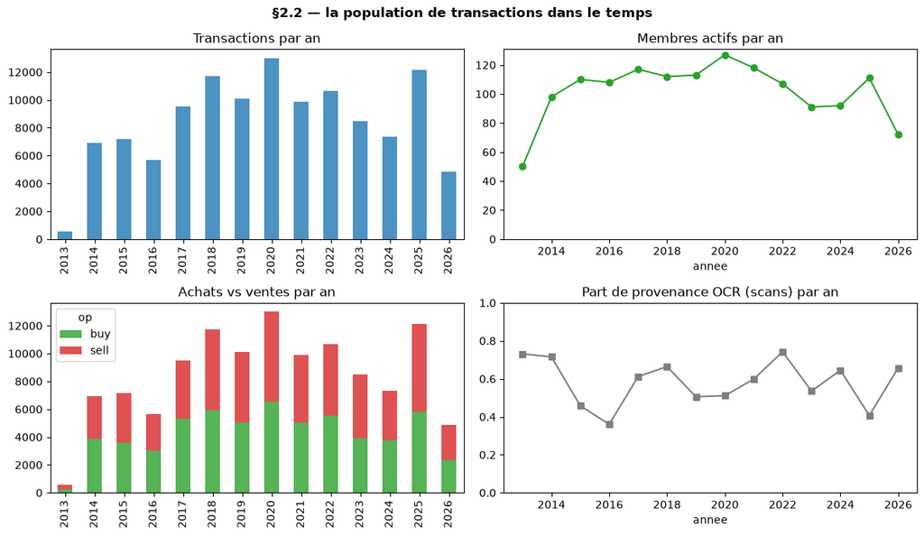

```
pic d'activité : 2020 (12993 trades) | achats 50.8% / ventes 49.2%
```

```python
# trades/an, membres actifs/an, buy vs sell, part de provenance OCR (contrôle du creux de collecte)
dfx["annee"] = dfx["traded"].dt.year
_by = dfx.groupby("annee")
fig, ax = plt.subplots(2, 2, figsize=(12, 7))
_by.size().plot(kind="bar", ax=ax[0,0], color="tab:blue", alpha=.8)
ax[0,0].set_title("Transactions par an"); ax[0,0].set_xlabel("")
_by["bioguide_id"].nunique().plot(kind="line", marker="o", ax=ax[0,1], color="tab:green")
ax[0,1].set_title("Membres actifs par an"); ax[0,1].set_ylim(0, None)
_bs = dfx.groupby(["annee","op"]).size().unstack(fill_value=0)
_bs.plot(kind="bar", stacked=True, ax=ax[1,0], color={"buy":"tab:green","sell":"tab:red"}, alpha=.8)
ax[1,0].set_title("Achats vs ventes par an"); ax[1,0].set_xlabel("")
_prov = dfx.assign(ocr=dfx.provenance.str.contains("ocr", case=False, na=False)).groupby("annee")["ocr"].mean()
_prov.plot(kind="line", marker="s", ax=ax[1,1], color="tab:gray")
ax[1,1].set_title("Part de provenance OCR (scans) par an"); ax[1,1].set_ylim(0,1)
fig.suptitle("§2.2 — la population de transactions dans le temps", fontweight="bold")
plt.tight_layout(); plt.show()
print(f"pic d'activité : {_by.size().idxmax()} ({_by.size().max()} trades) | achats {(dfx.op=='buy').mean():.1%} / ventes {(dfx.op=='sell').mean():.1%}")
```

### 2.3 Concentration de l'activité : une poignée de membres fait l'essentiel

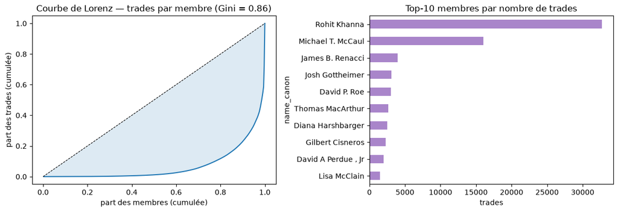

```
Gini = 0.861 (0 = égalité, 1 = un seul trade tout) | les 2 plus actifs = 41% des lignes
⚠ CONSÉQUENCE : une stat calculée PAR TRADE ≠ une stat calculée PAR MEMBRE. On affichera les deux.
```

```python
# courbe de Lorenz + Gini des trades par membre ; top-10
_tpm = dfx.groupby("bioguide_id").size().sort_values()
_x = np.arange(1, len(_tpm)+1) / len(_tpm)
_lor = np.cumsum(_tpm.values) / _tpm.sum()
def gini(x):
    x = np.sort(np.asarray(x, float)); n = len(x)
    return 1 - 2*np.sum((n - np.arange(1, n+1) + 0.5) * x) / (n * x.sum())
G = gini(_tpm.values)
fig, ax = plt.subplots(1, 2, figsize=(12, 4.2))
ax[0].plot(_x, _lor, color="tab:blue"); ax[0].plot([0,1],[0,1],"k--",lw=.8)
ax[0].fill_between(_x, _lor, _x, alpha=.15); ax[0].set_title(f"Courbe de Lorenz — trades par membre (Gini = {G:.2f})")
ax[0].set_xlabel("part des membres (cumulée)"); ax[0].set_ylabel("part des trades (cumulée)")
_top = dfx.groupby("name_canon").size().sort_values(ascending=False).head(10)
_top.iloc[::-1].plot(kind="barh", ax=ax[1], color="tab:purple", alpha=.8)
ax[1].set_title("Top-10 membres par nombre de trades"); ax[1].set_xlabel("trades")
plt.tight_layout(); plt.show()
_two = _tpm.tail(2).sum()
print(f"Gini = {G:.3f} (0 = égalité, 1 = un seul trade tout) | les 2 plus actifs = {_two/len(dfx):.0%} des lignes")
print("⚠ CONSÉQUENCE : une stat calculée PAR TRADE ≠ une stat calculée PAR MEMBRE. On affichera les deux.")
```

### 2.4 Chambres, partis, propriétaires

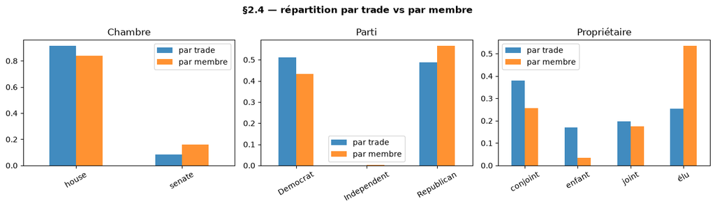

```
owner par trade : {'conjoint': 0.379, 'élu': 0.254, 'joint': 0.197, 'enfant': 0.17}
```

```python
fig, ax = plt.subplots(1, 3, figsize=(13, 3.8))
for a, col, titre in [(ax[0],"chamber","Chambre"), (ax[1],"party","Parti"), (ax[2],"owner_n","Propriétaire")]:
    _vc_tr = dfx[col].value_counts(normalize=True)
    _vc_mb = dfx.groupby("bioguide_id")[col].agg(lambda s: s.mode().iloc[0] if len(s.mode()) else np.nan).value_counts(normalize=True)
    _cmp = pd.DataFrame({"par trade": _vc_tr, "par membre": _vc_mb}).fillna(0)
    _cmp.plot(kind="bar", ax=a, color=["tab:blue","tab:orange"], alpha=.85)
    a.set_title(titre); a.set_xlabel(""); a.tick_params(axis="x", rotation=30)
fig.suptitle("§2.4 — répartition par trade vs par membre", fontweight="bold")
plt.tight_layout(); plt.show()
print("owner par trade :", dfx.owner_n.value_counts(normalize=True).round(3).to_dict())
```

- Lecture : House domine largement le **flux** ($\sim$91 % des trades) mais l'écart se réduit **par membre** ; parti $\approx$ 50/50 ; le **conjoint** exécute plus de trades que l'élu lui-même (charnière du narratif « Pelosi », testée au §5-§6).

### 2.5 Les tailles déclarées (brackets STOCK Act)

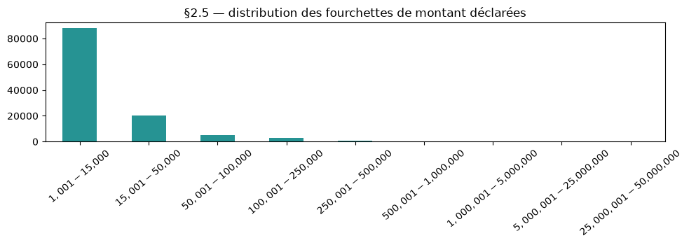

```
75% des trades sont à la 1re fourchette (midpoint 8 000,5 $).
⚠ le montant est une MESURE CENSURÉE PAR INTERVALLE : toute stat en $ (via midpoint) est une approximation ±facteur ~2.
```

```python
# histogramme ordonné des fourchettes ; part de la 1re fourchette
_order = ["$1,001 - $15,000","$15,001 - $50,000","$50,001 - $100,000","$100,001 - $250,000",
          "$250,001 - $500,000","$500,001 - $1,000,000","$1,000,001 - $5,000,000",
          "$5,000,001 - $25,000,000","$25,000,001 - $50,000,000","$50,000,000 +"]
_ar = dfx["amount_range"].value_counts()
_ar = _ar.reindex([o for o in _order if o in _ar.index])
fig, ax = plt.subplots(figsize=(10, 3.6))
_ar.plot(kind="bar", ax=ax, color="teal", alpha=.85)
ax.set_title("§2.5 — distribution des fourchettes de montant déclarées"); ax.set_xlabel("")
ax.tick_params(axis="x", rotation=40); plt.tight_layout(); plt.show()
_p1 = (dfx.size_usd <= 8000.5).mean()
print(f"{_p1:.0%} des trades sont à la 1re fourchette (midpoint 8 000,5 $).")
print("⚠ le montant est une MESURE CENSURÉE PAR INTERVALLE : toute stat en $ (via midpoint) est une approximation ±facteur ~2.")
```

### 2.6 La discipline de déclaration (délai `traded` → `disclosure`)

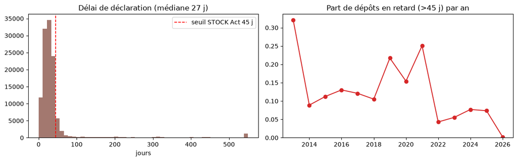

```
délai médian 27 j | p90 49 j | en retard (>45j) 11.7%
```

```python
fig, ax = plt.subplots(1, 2, figsize=(12, 3.8))
_lag = dfx["lag_days"].clip(lower=0)
ax[0].hist(_lag.clip(upper=_lag.quantile(.99)), bins=50, color="tab:brown", alpha=.8)
ax[0].axvline(45, color="red", ls="--", lw=1.2, label="seuil STOCK Act 45 j")
ax[0].set_title(f"Délai de déclaration (médiane {_lag.median():.0f} j)"); ax[0].set_xlabel("jours"); ax[0].legend()
_late = dfx.groupby("annee")["flag_late_filing"].mean()
_late.plot(kind="line", marker="o", ax=ax[1], color="tab:red")
ax[1].set_title("Part de dépôts en retard (>45 j) par an"); ax[1].set_ylim(0, None); ax[1].set_xlabel("")
plt.tight_layout(); plt.show()
print(f"délai médian {_lag.median():.0f} j | p90 {_lag.quantile(.9):.0f} j | en retard (>45j) {dfx.flag_late_filing.mean():.1%}")
```

### 2.7 Validation

On recalcule le Gini par une **formule alternative** (double somme des écarts absolus) et on vérifie les totaux.

```python
def gini_alt(x):
    x = np.asarray(x, float); n = len(x)
    return np.abs(np.subtract.outer(x, x)).sum() / (2 * n**2 * x.mean())
assert abs(gini(_tpm.values) - gini_alt(_tpm.values)) < 1e-9
assert dfx.groupby("annee").size().sum() == len(dfx)
print(f"validation §2 OK | Gini formule 1 = {gini(_tpm.values):.6f} ≡ formule 2 = {gini_alt(_tpm.values):.6f} | totaux croisés cohérents")
```

```
validation §2 OK | Gini formule 1 = 0.861485 ≡ formule 2 = 0.861485 | totaux croisés cohérents
```

## 3. Le comportement de chaque membre : le « style »

On construit une ligne par membre : rythme, direction, taille, délai, propriétaire, ancienneté, leadership. Puis on regarde la **concentration** des positions, le **turnover**, la **durée de détention**, et les **secteurs** préférés.

### 3.1 La table `beh` — un profil par membre

```python
# jointure ancienneté (table_congres) + leadership (fichier daté), agrégation PAR bioguide_id
_tc = pd.read_csv("/Users/lemairealice/Downloads/Jupiter/00. S3S4 en cours/table_congres_2014_2026.csv", low_memory=False)
_yio = _tc.dropna(subset=["bioguide_id"]).groupby("bioguide_id")["years_in_office"].max()
_lead = pd.read_csv(os.path.join(BASE, "leadership_2014_2026.csv"))
_leaders = set(_lead["bioguide_id"]) & set(wf_ret)

def _mode(s):
    m = s.mode(); return m.iloc[0] if len(m) else np.nan
_agg = dfx.groupby("bioguide_id")
beh = pd.DataFrame({
    "name": _agg["name_canon"].first(),
    "party": _agg["party"].agg(_mode), "chamber": _agg["chamber"].agg(_mode),
    "n_trades": _agg.size(),
    "buy_share": _agg["op"].agg(lambda s: (s=="buy").mean()),
    "taille_med": _agg["size_usd"].median(),
    "pct_1re_fourchette": _agg["size_usd"].agg(lambda s: (s<=8000.5).mean()),
    "lag_med": _agg["lag_days"].median(),
    "owner_dom": _agg["owner_n"].agg(_mode),
    "conjoint_share": _agg["owner_n"].agg(lambda s: (s=="conjoint").mean()),
    "n_tickers": _agg["ticker"].nunique(),
    "sect_dom": _agg["sector_gics"].agg(_mode),
})
beh["years_in_office"] = beh.index.map(_yio)
beh["leader"] = beh.index.isin(_leaders)
beh["n_days"] = beh.index.map({b: len(r) for b, r in wf_ret.items()})
_st = {b: stats(r) for b, r in wf_ret.items()}
for _k in ("sharpe", "vol", "cagr", "maxdd"):
    beh[_k] = beh.index.map({b: s[_k] for b, s in _st.items()})
beh = beh[beh.index.isin(wf_ret)].copy()          # les 266 reconstruits
beh["eligible"] = (beh.n_trades >= 10) & (beh.n_days >= 126)
print(f"beh : {len(beh)} membres ({beh.eligible.sum()} éligibles) | {beh.leader.sum()} leaders | "
      f"ancienneté connue : {beh.years_in_office.notna().mean():.0%}")
beh.sort_values("n_trades", ascending=False).head(6)[["name","party","chamber","n_trades","buy_share","conjoint_share","n_tickers","sharpe"]].round(2)
```

```
beh : 266 membres (223 éligibles) | 8 leaders | ancienneté connue : 89%
```

| bioguide_id | name | party | chamber | n_trades | buy_share | conjoint_share | n_tickers | sharpe |
| --- | --- | --- | --- | --- | --- | --- | --- | --- |
| K000389 | Rohit Khanna | Democrat | house | 32684 | 0.57 | 0.65 | 975 | 0.87 |
| M001157 | Michael T. McCaul | Republican | house | 16028 | 0.46 | 0.55 | 582 | 0.61 |
| R000586 | James B. Renacci | Republican | house | 3978 | 0.54 | 0.00 | 557 | 0.71 |
| G000583 | Josh Gottheimer | Democrat | house | 3054 | 0.41 | 0.00 | 478 | 0.78 |
| R000582 | David P. Roe | Republican | house | 3003 | 0.42 | 0.01 | 407 | 0.84 |
| M001193 | Thomas MacArthur | Republican | house | 2617 | 0.53 | 0.00 | 435 | 0.70 |

### 3.2 Concentration des positions (HHI, nombre effectif de lignes)

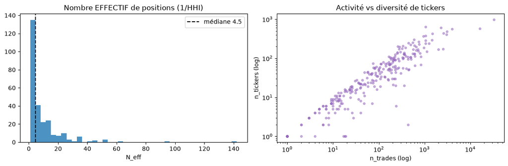

```
N_eff médian = 4.5 positions | poids top-1 moyen = 45% | beaucoup de portefeuilles sont TRÈS concentrés (N_eff < 5)
```

```python
# poids quotidiens w_i(t) = n_i(t)P_i(t)/V(t) ; HHI = moyenne sur jours actifs de Σ w_i² ; N_eff = 1/HHI
def concentration(bid):
    g = df[df.bioguide_id == bid]; N = member_shares(g)
    if N is None: return None
    P = pd.DataFrame({tk: prices[tk] for tk in N.columns})
    V = (N*P).sum(axis=1); act = V > 0
    if act.sum() == 0: return None
    W = (N*P).div(V, axis=0)[act]
    hhi = (W**2).sum(axis=1).mean()
    top1 = W.max(axis=1).mean()
    return dict(hhi=hhi, n_eff=1/hhi if hhi>0 else np.nan, top1=top1, n_pos_moy=(N[act]>0).sum(axis=1).mean())
_conc = {b: concentration(b) for b in wf_ret}
_conc = pd.DataFrame({b: v for b, v in _conc.items() if v}).T
beh = beh.join(_conc)
fig, ax = plt.subplots(1, 2, figsize=(12, 4))
ax[0].hist(beh.n_eff.dropna(), bins=40, color="tab:blue", alpha=.8)
ax[0].axvline(beh.n_eff.median(), color="k", ls="--", label=f"médiane {beh.n_eff.median():.1f}")
ax[0].set_title("Nombre EFFECTIF de positions (1/HHI)"); ax[0].set_xlabel("N_eff"); ax[0].legend()
ax[1].scatter(beh.n_trades, beh.n_tickers, s=12, alpha=.5, color="tab:purple")
ax[1].set_xscale("log"); ax[1].set_yscale("log"); ax[1].set_xlabel("n_trades (log)"); ax[1].set_ylabel("n_tickers (log)")
ax[1].set_title("Activité vs diversité de tickers")
plt.tight_layout(); plt.show()
print(f"N_eff médian = {beh.n_eff.median():.1f} positions | poids top-1 moyen = {beh.top1.mean():.0%} "
      f"| beaucoup de portefeuilles sont TRÈS concentrés (N_eff < 5)")
```

### 3.3 Turnover et saisonnalité

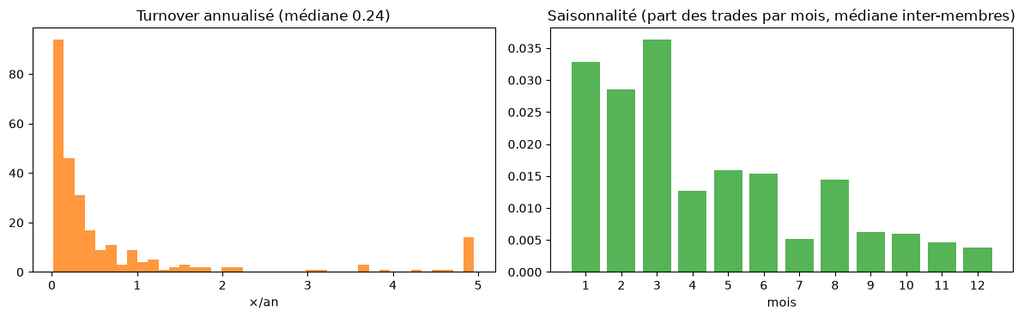

```
turnover médian 0.24×/an | ⚠ un burst mensuel peut refléter un rythme de courtier/trust, pas du market timing
```

```python
# turnover annualisé = (achats$ + ventes$) / (2 * valeur moyenne) * 252/T ; saisonnalité PAR MEMBRE (médiane)
def turnover(bid):
    g = df[df.bioguide_id == bid]; N = member_shares(g)
    if N is None: return np.nan
    P = pd.DataFrame({tk: prices[tk] for tk in N.columns}); V = (N*P).sum(axis=1); act = V > 0
    if act.sum() < 2: return np.nan
    flux = g["size_usd"].sum()
    return flux / (2 * V[act].mean()) * 252 / act.sum() if V[act].mean() > 0 else np.nan
beh["turnover"] = [turnover(b) for b in beh.index]
# saisonnalité : part des trades par mois, médiane inter-membres (pas pooled : Khanna écrase)
_mois_membre = dfx.groupby(["bioguide_id", dfx.traded.dt.month]).size()
_mois_share = _mois_membre.groupby(level=0).apply(lambda s: s/s.sum()).unstack(fill_value=0)
_seas = _mois_share.median()
fig, ax = plt.subplots(1, 2, figsize=(12, 3.8))
ax[0].hist(beh.turnover.replace([np.inf,-np.inf],np.nan).dropna().clip(upper=beh.turnover.quantile(.95)), bins=40, color="tab:orange", alpha=.8)
ax[0].set_title(f"Turnover annualisé (médiane {beh.turnover.median():.2f})"); ax[0].set_xlabel("×/an")
ax[1].bar(range(1,13), _seas.reindex(range(1,13)).values, color="tab:green", alpha=.8)
ax[1].set_title("Saisonnalité (part des trades par mois, médiane inter-membres)"); ax[1].set_xlabel("mois"); ax[1].set_xticks(range(1,13))
plt.tight_layout(); plt.show()
print(f"turnover médian {beh.turnover.median():.2f}×/an | ⚠ un burst mensuel peut refléter un rythme de courtier/trust, pas du market timing")
```

### 3.4 Durée de détention — appariement FIFO en parts

Pour chaque $(\text{membre}, \text{ticker})$, on apparie les ventes aux achats en **FIFO** (premier entré, premier sorti), avec **exactement** le même prix effectif et le même plafond anti-short que le moteur. Les parts encore détenues à la fin sont **censurées** (le membre pouvait encore vendre). On code une **Kaplan-Meier** à la main pour en tenir compte.

```python
from collections import deque
LAST_DAY = cal.max()
def fifo_holding(g):
    closed, opened = [], []          # (durée_j, parts) fermés ; (durée_censurée_j, parts) ouverts
    for tk, gt in g.groupby("ticker"):
        lots = deque()
        for _, row in gt.sort_values("traded").iterrows():        # MÊME tri que member_shares (garantit la conservation)
            dd, p = eff_price(tk, row["traded"])
            if dd is None: continue
            q = row["size_usd"] / p
            if row["op"] == "buy":
                lots.append([dd, q])
            else:
                held = sum(l[1] for l in lots); qv = min(q, held); take_tot = qv
                while take_tot > 1e-12 and lots:
                    tau_b, parts = lots[0]; take = min(parts, take_tot)
                    closed.append(((dd - tau_b).days, take)); take_tot -= take
                    if parts - take <= 1e-12: lots.popleft()
                    else: lots[0][1] = parts - take
        for tau_b, parts in lots:
            if parts > 1e-9:
                opened.append(((LAST_DAY - tau_b).days, parts))
    return closed, opened
# passe sur tous les membres
_CL, _OP = [], []
_open_by_mt = {}
for b in wf_ret:
    c, o = fifo_holding(df[df.bioguide_id == b]); _CL += c; _OP += o
closed = pd.DataFrame(_CL, columns=["duree","parts"]); opened = pd.DataFrame(_OP, columns=["duree","parts"])
_dur_med = np.median(np.repeat(closed.duree.values, np.maximum(1,(closed.parts.values/closed.parts.min()).round().astype(int).clip(max=50))))
_pct_open = opened.parts.sum() / (closed.parts.sum() + opened.parts.sum())
print(f"épisodes fermés : {len(closed)} | encore ouverts (censurés) : {len(opened)} | "
      f"part des parts achetées encore détenues à fin 2026 : {_pct_open:.0%}")
```

```
épisodes fermés : 61963 | encore ouverts (censurés) : 28944 | part des parts achetées encore détenues à fin 2026 : 44%
```

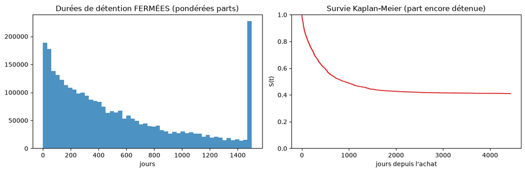

```
médiane de survie KM ≈ 910 j
```

```python
# Kaplan-Meier pondéré par les parts (événement = clôture ; censure = encore détenu à fin de fenêtre)
def km_weighted(closed, opened):
    ev = pd.DataFrame({"t": closed.duree, "w": closed.parts, "event": 1})
    ce = pd.DataFrame({"t": opened.duree, "w": opened.parts, "event": 0})
    alld = pd.concat([ev, ce]).sort_values("t")
    times = np.sort(ev["t"].unique())
    S, surv, cur = 1.0, [], alld
    xs, ys = [0],[1.0]
    for t in times:
        at_risk = alld.loc[alld.t >= t, "w"].sum()
        d = ev.loc[ev.t == t, "w"].sum()
        if at_risk > 0:
            S *= (1 - d/at_risk)
        xs.append(t); ys.append(S)
    return np.array(xs), np.array(ys)
_kx, _ky = km_weighted(closed, opened)
fig, ax = plt.subplots(1, 2, figsize=(12, 4))
_w = np.maximum(1,(closed.parts.values/closed.parts.min()).round().astype(int).clip(max=50))
ax[0].hist(np.repeat(closed.duree.values,_w).clip(max=1500), bins=50, color="tab:blue", alpha=.8)
ax[0].set_title("Durées de détention FERMÉES (pondérées parts)"); ax[0].set_xlabel("jours")
ax[1].step(_kx, _ky, where="post", color="tab:red"); ax[1].set_ylim(0,1)
ax[1].set_title("Survie Kaplan-Meier (part encore détenue)"); ax[1].set_xlabel("jours depuis l'achat"); ax[1].set_ylabel("S(t)")
plt.tight_layout(); plt.show()
_med_km = _kx[np.searchsorted(-_ky, -0.5)] if _ky.min() <= 0.5 else np.nan
print(f"médiane de survie KM ≈ {_med_km:.0f} j" if np.isfinite(_med_km) else "médiane KM non atteinte (>50% encore détenu) — détention LONGUE, pas du day-trading")
```

#### 3.4.1 Validation

Mini-exemple à durées connues à la main + **loi de conservation** : parts fermées + ouvertes $\equiv$ parts achetées (post-plafond) et parts ouvertes $\equiv$ `member_shares` final, sur tous les $(\text{membre},\text{ticker})$.

```python
# (a) mini-exemple synthétique : 1 achat, 1 vente partielle -> durée = (jour de vente effectif − achat effectif) exacte
_ex = pd.DataFrame({"ticker":["AAPL","AAPL"], "op":["buy","sell"],
                    "traded":pd.to_datetime(["2020-01-06","2020-06-01"]), "size_usd":[10000.0, 4000.0]})
_c, _o = fifo_holding(_ex)
_dd_b, _ = eff_price("AAPL", pd.Timestamp("2020-01-06")); _dd_s, _ = eff_price("AAPL", pd.Timestamp("2020-06-01"))
assert len(_c) == 1 and _c[0][0] == (_dd_s - _dd_b).days, _c
# (b) loi de conservation sur tous les membres : parts ouvertes FIFO ≡ member_shares final
_bad = 0
for b in list(wf_ret)[:60]:                 # échantillon (coûteux) — représentatif
    g = df[df.bioguide_id == b]; N = member_shares(g)
    c, o = fifo_holding(g)
    open_fifo = sum(p for _, p in o)
    open_ms = float((N.iloc[-1][N.iloc[-1] > 1e-9]).sum())
    if abs(open_fifo - open_ms) > 1e-6 * max(1, open_ms): _bad += 1
assert _bad == 0, _bad
print(f"validation §3.4 OK | (a) durée mini-exemple = {_c[0][0]} j exacte | "
      f"(b) conservation parts ouvertes FIFO ≡ member_shares sur 60 membres (0 écart)")
```

```
validation §3.4 OK | (a) durée mini-exemple = 147 j exacte | (b) conservation parts ouvertes FIFO ≡ member_shares sur 60 membres (0 écart)
```

### 3.5 Secteurs préférés (heatmap membre × GICS)

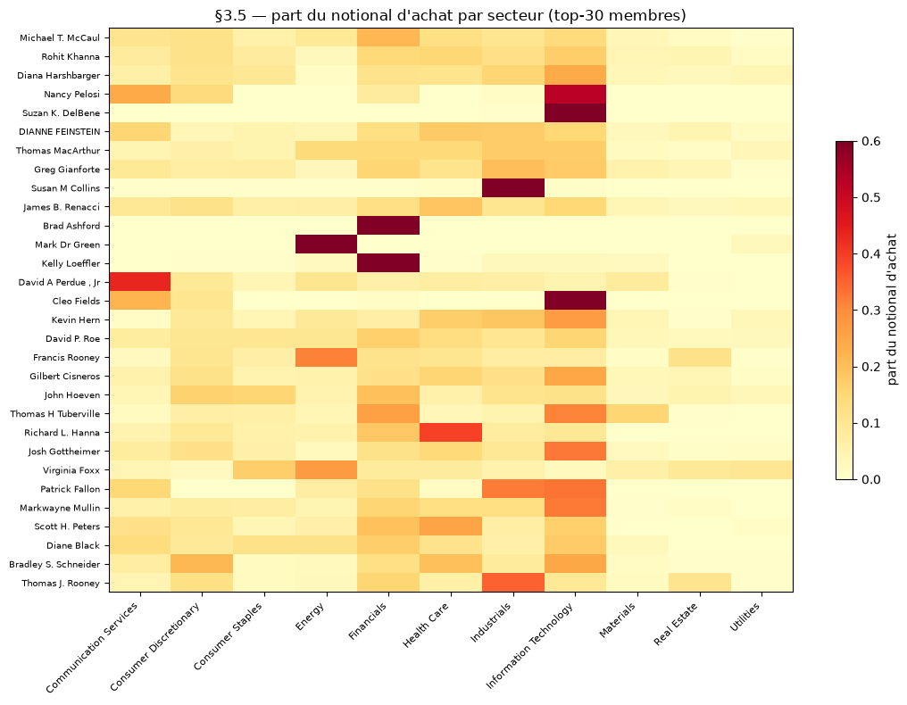

```
secteur dominant le plus fréquent : {'Information Technology': 82, 'Financials': 54, 'Consumer Discretionary': 28}
```

```python
# part du notional d'ACHAT par secteur, top-30 membres par notional
_ach = dfx[dfx.op == "buy"]
_notional = _ach.groupby("bioguide_id")["size_usd"].sum().sort_values(ascending=False)
_top30 = _notional.head(30).index
# NB pandas 3.0 : groupby(...).apply(...) ré-injecte la clé de groupe dans l'index
# (index à 3 niveaux) -> reindex(_top30) ne s'aligne plus -> heatmap toute blanche.
# Normalisation robuste : chaque (membre,secteur) / total d'achat du membre.
_g = _ach[_ach.bioguide_id.isin(_top30)].groupby(["bioguide_id","sector_gics"])["size_usd"].sum()
_hm = _g.div(_g.groupby(level=0).transform("sum")).unstack(fill_value=0)
_hm = _hm.reindex(_top30)
_hm.index = beh.reindex(_top30)["name"].values
fig, ax = plt.subplots(figsize=(11, 8))
im = ax.imshow(_hm.values, aspect="auto", cmap="YlOrRd", vmin=0, vmax=0.6)
ax.set_xticks(range(len(_hm.columns))); ax.set_xticklabels(_hm.columns, rotation=45, ha="right", fontsize=8)
ax.set_yticks(range(len(_hm))); ax.set_yticklabels(_hm.index, fontsize=7)
ax.set_title("§3.5 — part du notional d'achat par secteur (top-30 membres)")
fig.colorbar(im, ax=ax, shrink=.6, label="part du notional d'achat")
plt.tight_layout(); plt.show()
print("secteur dominant le plus fréquent :", beh.sect_dom.value_counts().head(3).to_dict())
```

### 3.6 Deux limites à nommer

- **Home bias infaisable** : la table n'a **aucune** colonne de siège social des entreprises (`state_district` = l'élu, pas l'émetteur). Mesurer « achètent-ils près de chez eux » demanderait une table externe ticker→état du siège — hors périmètre.
- **Options absentes** : `asset_class` $\in$ {stock, etf, unknown}. Les options/LEAPS des PTR (célèbres chez Pelosi) ne sont **pas** dans la table ; toute NAV de ce notebook est **actions seulement** (renvoi §6).

## 4. Performance descriptive : qui « réussit », et le comportement explique-t-il ?

On décrit la distribution des performances des 223 éligibles, on regarde les extrêmes, puis on cherche des **corrélations descriptives** comportement↔performance — avec IC bootstrap et bande de permutation, pour **ne pas** rouvrir la chasse au signal que le 05b a fermée.

### 4.1 Distribution des performances

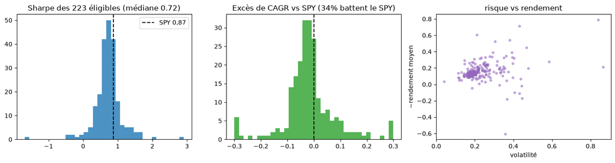

```
34% des éligibles battent le SPY sur LEUR fenêtre — à confronter au « 32 % » d'Unusual Whales (§6, année civile).
```

```python
_e = beh[beh.eligible].copy()
# excès de CAGR vs SPY aligné sur la fenêtre de CHAQUE membre
def exces_spy(bid):
    r = wf_ret[bid]; nav = (1+r).cumprod(); cagr = nav.iloc[-1]**(252/len(r))-1
    rs = r_spy.reindex(r.index).fillna(0.0); navs = (1+rs).cumprod(); cagrs = navs.iloc[-1]**(252/len(rs))-1
    return cagr - cagrs
_e["exces_cagr"] = [exces_spy(b) for b in _e.index]
_pct_bat = (_e.exces_cagr > 0).mean()
fig, ax = plt.subplots(1, 3, figsize=(14, 3.8))
ax[0].hist(_e.sharpe, bins=35, color="tab:blue", alpha=.8); ax[0].axvline(0.87, color="k", ls="--", label="SPY 0,87")
ax[0].set_title(f"Sharpe des {len(_e)} éligibles (médiane {_e.sharpe.median():.2f})"); ax[0].legend()
ax[1].hist(_e.exces_cagr.clip(-.3,.3), bins=35, color="tab:green", alpha=.8); ax[1].axvline(0, color="k", ls="--")
ax[1].set_title(f"Excès de CAGR vs SPY ({_pct_bat:.0%} battent le SPY)")
ax[2].scatter(_e.vol, _e.sharpe*_e.vol, s=12, alpha=.5, color="tab:purple")
ax[2].set_xlabel("volatilité"); ax[2].set_ylabel("~rendement moyen"); ax[2].set_title("risque vs rendement")
plt.tight_layout(); plt.show()
print(f"{_pct_bat:.0%} des éligibles battent le SPY sur LEUR fenêtre — à confronter au « 32 % » d'Unusual Whales (§6, année civile).")
```

### 4.2 Les extrêmes — mais face au hasard

⚠ La bonne référence n'est **pas** le $E[\max t]=2{,}69$ du 05b (qui portait sur 160 *stratégies*) mais la distribution du **max de $t$ sur $N$ membres** sous $H_0$. On la calcule par Monte-Carlo ($N$ membres iid, chacun $t \sim \mathcal{N}(0,1)$ — le filtre $\ge 252$ j rend le $t$ de Student quasi-gaussien) et on place le max observé dedans.

```
TOP-15 par Sharpe :
                             name       party chamber  n_trades  n_eff  sharpe     t  exces_cagr                sect_dom
bioguide_id
F000479            John Fetterman    Democrat  senate        10   2.09    2.90  3.08        0.55  Communication Services
B001319               Katie Britt  Republican  senate        24   8.28    2.02  2.23       -0.00  Information Technology
J000307                John James  Republican   house       257  51.52    1.72  2.78        0.03  Information Technology
M001220           Morgan McGarvey    Democrat   house        24   2.62    1.71  3.15        0.40  Information Technology
M001244              Ashley Moody  Republican  senate        23   4.58    1.66  1.99        0.68  Information Technology
W000821           Bruce Westerman  Republican   house       208  10.53    1.58  1.82        0.14              Financials
T000490           David J. Taylor  Republican   house       195   9.07    1.53  1.81        0.10  Information Technology
S001211              Greg Stanton    Democrat   house       186   5.69    1.48  2.46        0.06  Information Technology
M001136              Lisa McClain  Republican   house      1479   6.08    1.43  2.16        0.41  Information Technology
F000110               Cleo Fields    Democrat   house       213   4.10    1.40  1.46        0.10  Information Technology
L000601             Greg Landsman    Democrat   house       164   7.55    1.40  2.59        0.12  Information Technology
S000168      Maria Elvira Salazar  Republican   house        69   1.44    1.39  2.52        0.05  Information Technology
S001198         Daniel S Sullivan  Republican  senate       100   4.01    1.33  2.53        0.21  Information Technology
J000310             Julie Johnson    Democrat   house       491   2.35    1.30  1.97        0.16              Financials
L000595              Julia Letlow  Republican   house       224  43.96    1.29  1.67        0.07  Information Technology
```

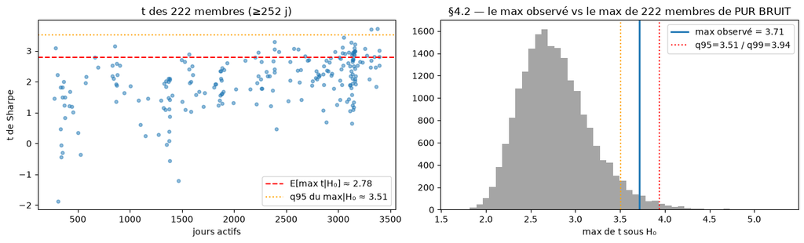

```
max t membre observé = 3.71 | sous H₀ (222 membres iid) : E[max]=2.78, q95=3.51, q99=3.94 → p(max≥3.71) ≈ 2.4%
→ le meilleur membre est un OUTLIER DE QUEUE (p≈2% sous H₀) : à peu près ce que le pur hasard produit sur ~222 membres, PAS une compétence démontrée.
  (05b §4.2 : ~20 membres « significatifs » à t>1,645 ≈ 11 attendus par hasard — même message au niveau du compte.)
```

```python
# top/bottom-15 par Sharpe (>=252 j) ; t = Sharpe·√(T/252)
_ee = _e[_e.n_days >= 252].copy()
_ee["t"] = _ee.sharpe * np.sqrt(_ee.n_days/252)
_cols = ["name","party","chamber","n_trades","n_eff","sharpe","t","exces_cagr","sect_dom"]
print("TOP-15 par Sharpe :"); print(_ee.sort_values("sharpe", ascending=False).head(15)[_cols].round(2).to_string())
# distribution du MAX de t sous H0 par Monte-Carlo (N membres de PUR BRUIT)
_Nm = len(_ee); _rng42 = np.random.default_rng(42)
_maxnull = _rng42.standard_normal((20000, _Nm)).max(axis=1)
_E, _q95, _q99 = _maxnull.mean(), np.quantile(_maxnull, .95), np.quantile(_maxnull, .99)
_tmax = _ee.t.max(); _p = (_maxnull >= _tmax).mean()
fig, ax = plt.subplots(1, 2, figsize=(13, 4))
ax[0].scatter(_ee.n_days, _ee.t, s=14, alpha=.5, color="tab:blue")
ax[0].axhline(_E, color="red", ls="--", label=f"E[max t|H₀] ≈ {_E:.2f}")
ax[0].axhline(_q95, color="orange", ls=":", label=f"q95 du max|H₀ ≈ {_q95:.2f}")
ax[0].set_xlabel("jours actifs"); ax[0].set_ylabel("t de Sharpe"); ax[0].set_title(f"t des {_Nm} membres (≥252 j)"); ax[0].legend()
ax[1].hist(_maxnull, bins=50, color="tab:gray", alpha=.7)
ax[1].axvline(_tmax, color="tab:blue", lw=2, label=f"max observé = {_tmax:.2f}")
ax[1].axvline(_q95, color="orange", ls=":"); ax[1].axvline(_q99, color="red", ls=":", label=f"q95={_q95:.2f} / q99={_q99:.2f}")
ax[1].set_xlabel("max de t sous H₀"); ax[1].set_title(f"§4.2 — le max observé vs le max de {_Nm} membres de PUR BRUIT"); ax[1].legend()
plt.tight_layout(); plt.show()
print(f"max t membre observé = {_tmax:.2f} | sous H₀ ({_Nm} membres iid) : E[max]={_E:.2f}, q95={_q95:.2f}, q99={_q99:.2f} → p(max≥{_tmax:.2f}) ≈ {_p:.1%}")
print(f"→ le meilleur membre est un OUTLIER DE QUEUE (p≈{_p:.0%} sous H₀) : à peu près ce que le pur hasard produit sur ~{_Nm} membres, PAS une compétence démontrée.")
print("  (05b §4.2 : ~20 membres « significatifs » à t>1,645 ≈ 11 attendus par hasard — même message au niveau du compte.)")
```

### 4.3 Comportement ↔ performance — le design anti-chasse

Pour chaque *feature* de comportement, on regarde le lien avec le Sharpe **sans** conclure à un signal : médiane par quartile + **IC bootstrap 95 %** (rééchantillonnage par membre), et un **forest plot** des corrélations de Spearman avec une **bande de permutation** (le bruit attendu sous $H_0$).

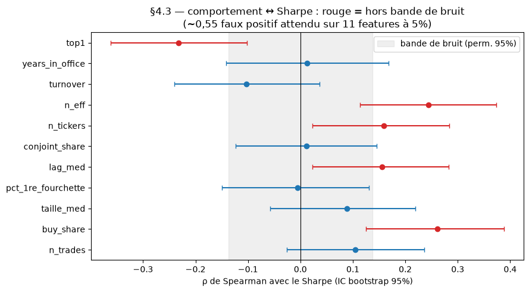

```
                      rho     lo     hi   band  hors_bruit
feature
n_trades            0.105 -0.026  0.236  0.132       False
buy_share           0.261  0.125  0.388  0.131        True
taille_med          0.089 -0.058  0.219  0.129       False
pct_1re_fourchette -0.005 -0.149  0.130  0.135       False
lag_med             0.155  0.023  0.283  0.131        True
conjoint_share      0.012 -0.123  0.145  0.128       False
n_tickers           0.159  0.023  0.283  0.124        True
n_eff               0.245  0.113  0.374  0.136        True
turnover           -0.103 -0.240  0.037  0.133       False
years_in_office     0.013 -0.142  0.168  0.137       False
top1               -0.233 -0.362 -0.102  0.129        True

features hors bande de bruit : ['buy_share', 'lag_med', 'n_tickers', 'n_eff', 'top1']
⚠ RAPPEL §17 du 05b : owner p 0,06 non répliqué ; taille (gros PIRES) non répliqué ; lag/parti/chambre/leadership rien.
   Ce §4.3 REDÉCRIT ces nulls ; il ne peut pas les renverser (inférence fermée au 05b).
```

```python
FEATS = ["n_trades","buy_share","taille_med","pct_1re_fourchette","lag_med",
         "conjoint_share","n_tickers","n_eff","turnover","years_in_office","top1"]
_D = _e.dropna(subset=["sharpe"]).copy()
rng = np.random.default_rng(7)
def boot_ci_spearman(x, y, B=2000):
    m = x.notna() & y.notna(); x, y = x[m].values, y[m].values; n = len(x)
    rho = sps.spearmanr(x, y).statistic
    idx = rng.integers(0, n, size=(B, n))
    bs = np.array([sps.spearmanr(x[i], y[i]).statistic for i in idx])
    return rho, np.nanquantile(bs, .025), np.nanquantile(bs, .975)
# bande de permutation (H0) : |rho| au hasard
def perm_band(x, y, B=1000):
    m = x.notna() & y.notna(); x, y = x[m].values, y[m].values
    ps = np.array([abs(sps.spearmanr(rng.permutation(x), y).statistic) for _ in range(B)])
    return np.quantile(ps, .95)
rows = []
for f in FEATS:
    rho, lo, hi = boot_ci_spearman(_D[f], _D["sharpe"])
    band = perm_band(_D[f], _D["sharpe"])
    rows.append(dict(feature=f, rho=rho, lo=lo, hi=hi, band=band, hors_bruit=abs(rho) > band))
forest = pd.DataFrame(rows).set_index("feature")
fig, ax = plt.subplots(figsize=(9, 5))
_y = range(len(forest))
ax.axvspan(-forest.band.max(), forest.band.max(), color="gray", alpha=.12, label="bande de bruit (perm. 95%)")
for i, (f, r) in enumerate(forest.iterrows()):
    c = "tab:red" if r.hors_bruit else "tab:blue"
    ax.errorbar(r.rho, i, xerr=[[r.rho-r.lo],[r.hi-r.rho]], fmt="o", color=c, capsize=3)
ax.axvline(0, color="k", lw=.8); ax.set_yticks(list(_y)); ax.set_yticklabels(forest.index)
ax.set_xlabel("ρ de Spearman avec le Sharpe (IC bootstrap 95%)")
ax.set_title("§4.3 — comportement ↔ Sharpe : rouge = hors bande de bruit\n(~0,55 faux positif attendu sur 11 features à 5%)")
ax.legend(); plt.tight_layout(); plt.show()
print(forest.round(3).to_string())
print(f"\nfeatures hors bande de bruit : {list(forest[forest.hors_bruit].index) or 'aucune'}")
print("⚠ RAPPEL §17 du 05b : owner p 0,06 non répliqué ; taille (gros PIRES) non répliqué ; lag/parti/chambre/leadership rien.")
print("   Ce §4.3 REDÉCRIT ces nulls ; il ne peut pas les renverser (inférence fermée au 05b).")
```

#### Lecture — ces corrélations sont **mécaniques**, pas des signaux

- **Diversification** : $N_\text{eff}\uparrow$ et poids top-1 $\downarrow$ $\to$ Sharpe $\uparrow$ est presque une **identité** (le Sharpe récompense la diversification du risque idiosyncratique) ; idem $n_\text{tickers}$. Ce n'est pas du talent — c'est la définition du Sharpe.
- **Régime** : $\texttt{buy\_share}\uparrow \to$ Sharpe $\uparrow$ sur une fenêtre 2014-2026 **haussière** est un effet de marché (être net long paie mécaniquement), pas une compétence de sélection.
- **Rien de copiable** : le 05b §17 a déjà testé, en **apparié** (chaque membre son propre témoin), si owner, taille, ventes, délai se traduisent en **excès copiable** $\to$ tous *null*. Ce §4.3 **redécrit** des régularités de style ; il ne peut pas rouvrir cette inférence.

### 4.4 Validation

IC bootstrap et Spearman recoupés avec `scipy.stats` (implémentation indépendante).

```python
_f = "n_eff"
_m = _D[_f].notna() & _D["sharpe"].notna()
_rho_scipy = sps.spearmanr(_D[_f][_m], _D["sharpe"][_m]).statistic
assert abs(forest.loc[_f,"rho"] - _rho_scipy) < 1e-9
_res = sps.bootstrap((_D[_f][_m].values, _D["sharpe"][_m].values),
                     lambda a,b,axis=None: sps.spearmanr(a,b).statistic if a.ndim==1 else
                     np.array([sps.spearmanr(a[i],b[i]).statistic for i in range(a.shape[0])]),
                     paired=True, n_resamples=1000, random_state=1, vectorized=False)
print(f"validation §4 OK | ρ({_f}) maison {forest.loc[_f,'rho']:.4f} ≡ scipy {_rho_scipy:.4f} | "
      f"IC scipy.bootstrap [{_res.confidence_interval.low:.3f}; {_res.confidence_interval.high:.3f}] ≈ maison [{forest.loc[_f,'lo']:.3f}; {forest.loc[_f,'hi']:.3f}]")
```

```
validation §4 OK | ρ(n_eff) maison 0.2446 ≡ scipy 0.2446 | IC scipy.bootstrap [0.116; 0.365] ≈ maison [0.113; 0.374]
```

## 5. Études de cas : six membres, six styles

Une fiche par membre médiatisé : NAV reconstruite (actions) vs SPY, timeline des trades, poids des positions, excès annuel. On confronte la **réputation** (chiffres publics, §6) à ce que **nos données** montrent.

```python
def fiche_membre(bid, zoom=None):
    g = df[df.bioguide_id == bid].sort_values("traded")
    gx = dfx[dfx.bioguide_id == bid]
    nom = beh.loc[bid, "name"] if bid in beh.index else bid
    r = wf_ret[bid]; nav = 100*(1+r).cumprod()
    rs = r_spy.reindex(r.index).fillna(0.0); navs = 100*(1+rs).cumprod()
    N = member_shares(g); P = pd.DataFrame({tk: prices[tk] for tk in N.columns}); V=(N*P).sum(axis=1); act=V>0
    W = (N*P).div(V, axis=0)[act]
    top8 = W.mean().sort_values(ascending=False).head(8).index
    fig, ax = plt.subplots(2, 2, figsize=(13, 7))
    ax[0,0].plot(nav.index, nav.values, color="tab:blue", label=nom)
    ax[0,0].plot(navs.index, navs.values, color="k", lw=1.2, label="SPY")
    ax[0,0].set_yscale("log"); ax[0,0].set_title(f"(A) NAV actions base 100 vs SPY"); ax[0,0].legend()
    for op, c in [("buy","tab:green"),("sell","tab:red")]:
        s = gx[gx.op==op]; ax[0,1].scatter(s.traded, s.size_usd, s=14, c=c, alpha=.5, label=op)
    ax[0,1].set_yscale("log"); ax[0,1].set_title("(B) timeline des trades (taille $, log)"); ax[0,1].legend()
    if len(top8):
        W[top8].plot.area(ax=ax[1,0], lw=0, alpha=.8, cmap="tab10")
        ax[1,0].set_title("(C) poids des 8 principales positions"); ax[1,0].legend(fontsize=6, ncol=2); ax[1,0].set_ylim(0,1)
    _ye = pd.Series({y: ((1+r[r.index.year==y]).prod()-1) - ((1+rs[rs.index.year==y]).prod()-1)
                     for y in sorted(set(r.index.year))})
    ax[1,1].bar(_ye.index, 100*_ye.values, color=["tab:green" if v>0 else "tab:red" for v in _ye.values], alpha=.8)
    ax[1,1].axhline(0, color="k", lw=.8); ax[1,1].set_title("(D) excès annuel vs SPY (%)")
    if zoom:
        for a in [ax[0,0], ax[0,1]]: a.set_xlim(pd.Timestamp(zoom[0]), pd.Timestamp(zoom[1]))
    fig.suptitle(f"{nom} — {len(g)} trades | Sharpe {stats(r)['sharpe']:.2f} | N_eff {beh.loc[bid,'n_eff']:.1f} | "
                 f"conjoint {beh.loc[bid,'conjoint_share']:.0%} | lag méd {beh.loc[bid,'lag_med']:.0f} j", fontweight="bold")
    plt.tight_layout(); plt.show()
print("helper fiche_membre prêt.")
```

```
helper fiche_membre prêt.
```

### 5.1 Nancy Pelosi (P000197) — l'hyper-médiatisée

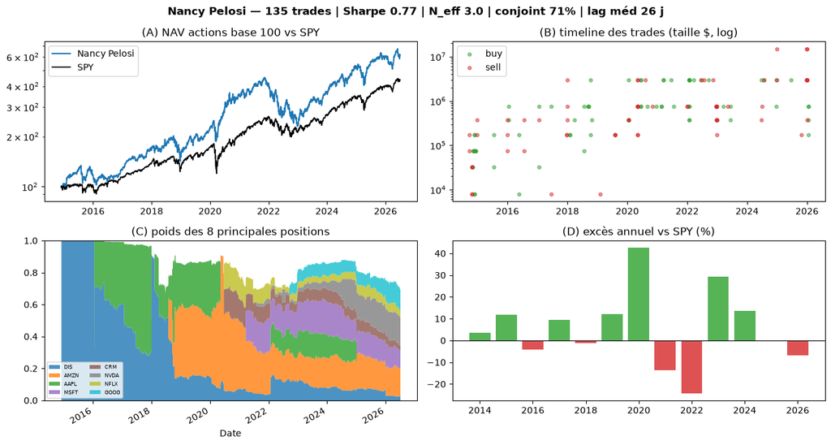

```python
fiche_membre("P000197")
```

### 5.2 Ro Khanna (K000389) — l'anti-Pelosi : des milliers de micro-trades diversifiés (trusts familiaux)

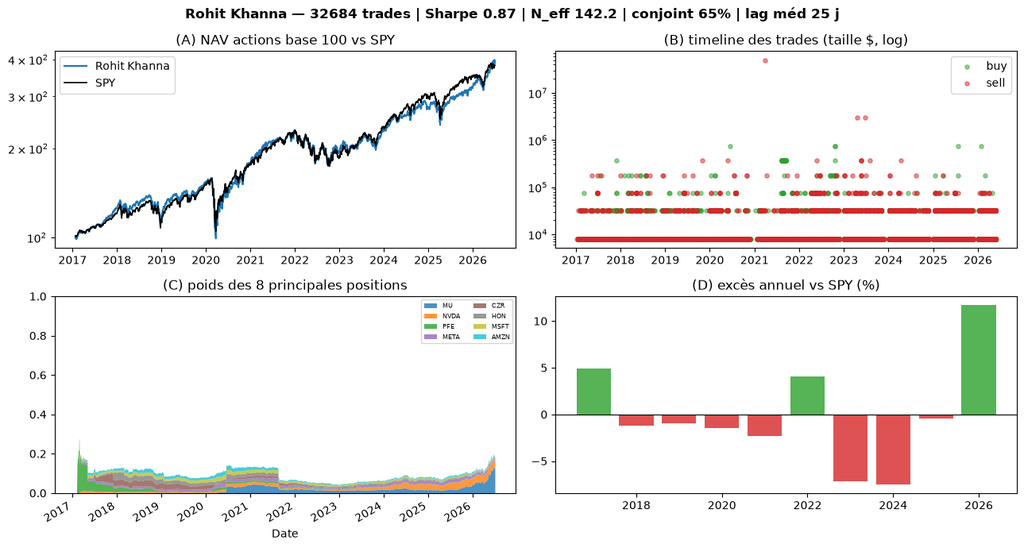

```python
fiche_membre("K000389")
```

### 5.3 Michael McCaul (M001157) — le 2ᵉ plus actif, fortune familiale, comité Foreign Affairs

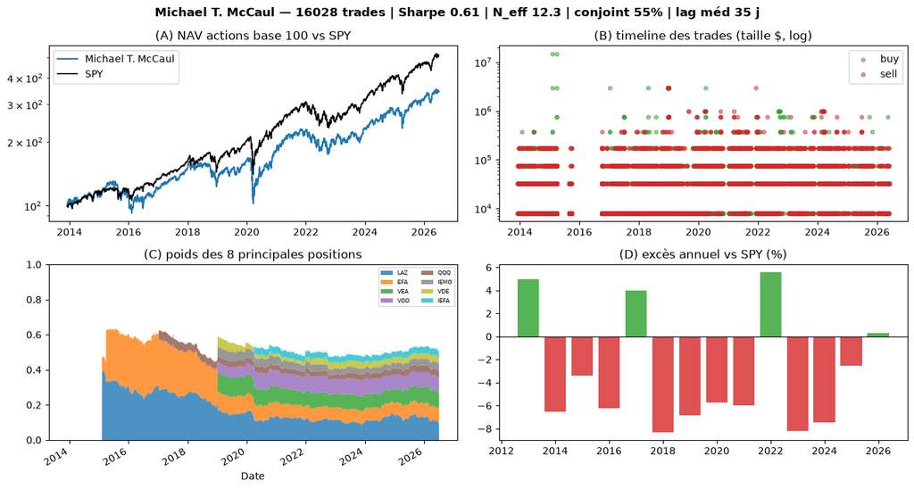

```python
fiche_membre("M001157")
```

### 5.4 Josh Gottheimer (G000583) — le « day-trader » médiatique, gros turnover

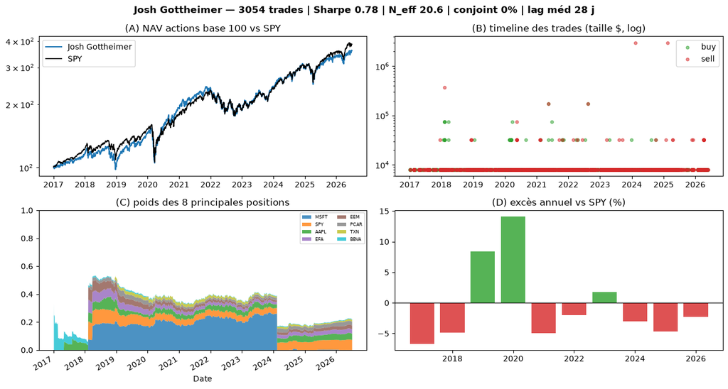

```python
fiche_membre("G000583")
```

### 5.5 Tommy Tuberville (T000278) — sénateur aux déclarations souvent tardives

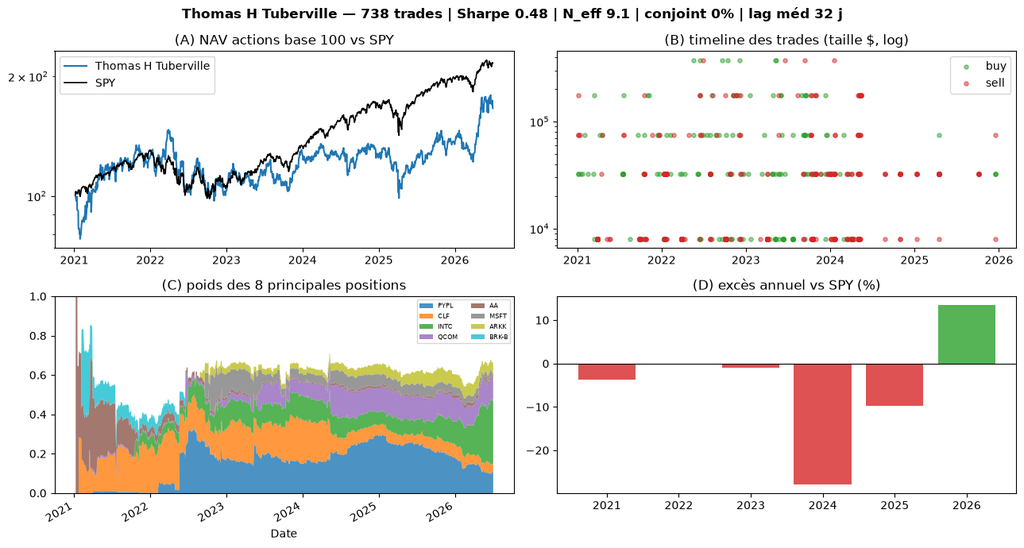

```python
fiche_membre("T000278")
```

### 5.6 Richard Burr (B001135) — le scandale COVID de février 2020

Zoom janv.-mars 2020 : nos données montrent-elles la vente massive avant le krach ? (DOJ/SEC ont clos sans charge.) Kelly Loeffler (L000594) et Feinstein (F000062) ont eu des ventes similaires à la même période.

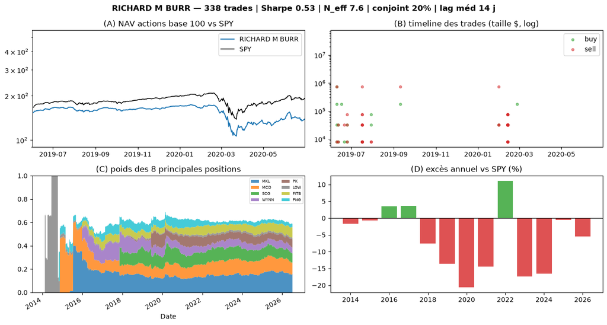

```python
fiche_membre("B001135", zoom=("2019-06-01","2020-06-30"))
```

## 6. Hype vs réalité : pourquoi nos chiffres ne ressemblent pas à ceux des trackers

Les chiffres publics ci-dessous sont **vérifiés** (état de l'art, Phase 2 — sources primaires). On les confronte à **notre** reconstruction actions-seulement.

```python
# chiffres publics GELÉS (vérifiés en Phase 2 ; pas de fetch à l'exécution) — source + date d'accès
HYPE = {
    "Pelosi 2024 — Unusual Whales (options incluses)":       0.709,
    "Pelosi 2024 — Autopilot (actions, ~2 sem. de délai)":   0.54,
    "S&P 500 — 2024":                                        0.249,
    "ETF NANC — annualisé depuis 2023 (beta tech)":          0.2358,
    "S&P 500 TR — annualisé depuis 2023":                    0.2106,
    "Quiver « Congress Buys » — CAGR backtest (β 1,14, sans coûts)": 0.3715,
}
# notre reconstruction actions-only de Pelosi, année civile 2024
_rp = wf_ret["P000197"]; _2024 = _rp[_rp.index.year == 2024]
_pelosi_2024_actions = (1+_2024).prod() - 1
print("CHIFFRES PUBLICS VÉRIFIÉS (Phase 2) :")
for k, v in HYPE.items(): print(f"  {k:58s} {v:+.1%}")
print(f"\nNOTRE reconstruction Pelosi 2024 (ACTIONS SEULEMENT) : {_pelosi_2024_actions:+.1%}")
print(f"% de nos membres battant le SPY (§4.1) : {_pct_bat:.0%}  vs  Unusual Whales 2025 : 32 %")
```

```
CHIFFRES PUBLICS VÉRIFIÉS (Phase 2) :
  Pelosi 2024 — Unusual Whales (options incluses)            +70.9%
  Pelosi 2024 — Autopilot (actions, ~2 sem. de délai)        +54.0%
  S&P 500 — 2024                                             +24.9%
  ETF NANC — annualisé depuis 2023 (beta tech)               +23.6%
  S&P 500 TR — annualisé depuis 2023                         +21.1%
  Quiver « Congress Buys » — CAGR backtest (β 1,14, sans coûts) +37.1%

NOTRE reconstruction Pelosi 2024 (ACTIONS SEULEMENT) : +38.5%
% de nos membres battant le SPY (§4.1) : 34%  vs  Unusual Whales 2025 : 32 %
```

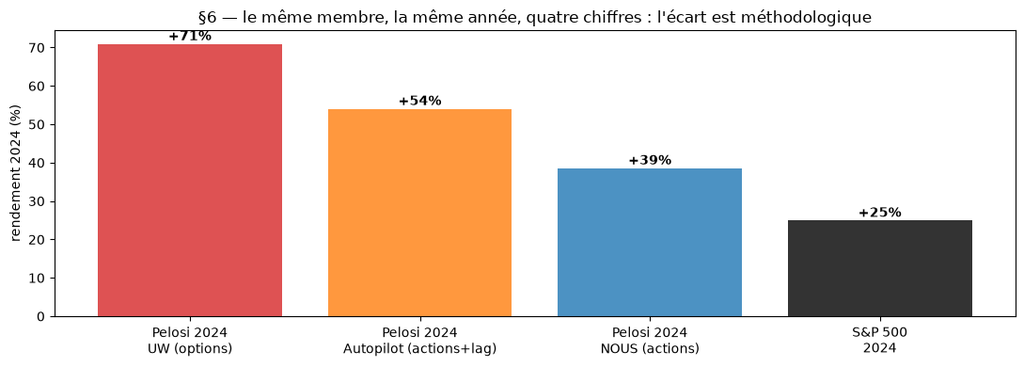

```python
# barres appariées : la hype vs notre reconstruction
fig, ax = plt.subplots(figsize=(11, 4))
_lbl = ["Pelosi 2024\nUW (options)","Pelosi 2024\nAutopilot (actions+lag)","Pelosi 2024\nNOUS (actions)","S&P 500\n2024"]
_val = [0.709, 0.54, _pelosi_2024_actions, 0.249]
ax.bar(_lbl, [100*v for v in _val], color=["tab:red","tab:orange","tab:blue","k"], alpha=.8)
for i, v in enumerate(_val): ax.text(i, 100*v+1, f"{v:+.0%}", ha="center", fontweight="bold")
ax.set_ylabel("rendement 2024 (%)"); ax.set_title("§6 — le même membre, la même année, quatre chiffres : l'écart est méthodologique")
plt.tight_layout(); plt.show()
```

### 6.1 Lecture — d'où vient l'écart

1. **Options / LEAPS exclues** de notre table : le levier NVDA/GOOGL/AVGO de Pelosi 2023-24 vit précisément là. C'est le **premier** facteur (UW $+70{,}9\%$ → Autopilot actions $+54\%$ → nous, actions, encore moins).
2. **Sizing midpoint** vs positions/fills réels.
3. **Méthodo tracker** : pondérations, fenêtre (année civile vs depuis-trade), pas de time-weighting.
4. **Survivorship narratif** : on ne cite que les années et les membres gagnants (UW 2025 : seulement **32 %** battent le marché ; NANC = un **beta tech**, GOP fait *moins* que le S&P).

**Pourquoi Pelosi maintenant (juillet 2026)** : retraite annoncée (nov. 2025) → dernière année de trades traçables ; le **PELOSI Act** (ban du trading) porte son nom et avance en commission ; le rapport UW 2025 a relancé le débat. La leçon : **plus une mesure est réplicable (actions, délai réel, coûts), plus le chiffre baisse** — c'est pourquoi *nos* chiffres sont bas, et justes.

## 7. Ce que la littérature capte, et ce que nous voyons

Synthèse (papier `PAPIER_ETAT_DE_LART.pdf`) : ce qui est **fermé** chez nous, ce qui reste **ouvert**.

```python
LIT = pd.DataFrame([
    ("Belmont 2022","6 mois","null (achats −26 bps)","répliqué (03/04/05/05b)","fermé"),
    ("Ziobrowski 2004","transaction","+85 bps/mois, mort après 96","non copiable","fermé"),
    ("05b §16 commission","portefeuille","Δ≈0 aux 2 niveaux","notre test","fermé"),
    ("05b §17 dimensions","apparié","ère/owner/ventes/taille/lag: rien","notre test","fermé"),
    ("Lazzaretto 2024","DISCLOSURE","+90 bps le mois post-divulg.","NON testé (05b=12m)","OUVERT"),
    ("Pyun 2025","DISCLOSURE","value-weight achats α>0 (large-cap/House/post-2020)","NON testé","OUVERT"),
    ("Wei-Zhou 2025","les deux","12 leaders +47 pts/an","SUPP_A sous-puissant","OUVERT"),
    ("Abdurakhmonov 2023","disclosure","+50 bps si juridiction comité","event-study court non fait","partiel"),
    ("Herron 2026 herding","—","co-achat dégrade","descriptif ci-dessous","ouvert"),
    ("Molk-Partnoy 2025","10-15 j","trades négatifs +1-2% (OPTIONS)","pas d'options chez nous","non testable"),
], columns=["source","événement","résultat","notre statut","verdict"])
print(LIT.to_string(index=False))
```

```
             source    événement                                            résultat               notre statut      verdict
       Belmont 2022       6 mois                               null (achats −26 bps)    répliqué (03/04/05/05b)        fermé
    Ziobrowski 2004  transaction                         +85 bps/mois, mort après 96               non copiable        fermé
 05b §16 commission portefeuille                                   Δ≈0 aux 2 niveaux                 notre test        fermé
 05b §17 dimensions      apparié                   ère/owner/ventes/taille/lag: rien                 notre test        fermé
    Lazzaretto 2024   DISCLOSURE                        +90 bps le mois post-divulg.        NON testé (05b=12m)       OUVERT
          Pyun 2025   DISCLOSURE value-weight achats α>0 (large-cap/House/post-2020)                  NON testé       OUVERT
      Wei-Zhou 2025     les deux                               12 leaders +47 pts/an       SUPP_A sous-puissant       OUVERT
 Abdurakhmonov 2023   disclosure                       +50 bps si juridiction comité event-study court non fait      partiel
Herron 2026 herding            —                                    co-achat dégrade      descriptif ci-dessous       ouvert
  Molk-Partnoy 2025      10-15 j                     trades négatifs +1-2% (OPTIONS)    pas d'options chez nous non testable
```

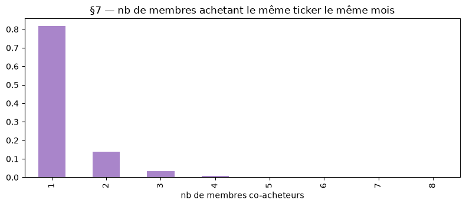

```
part des (ticker,mois) achetés par ≥3 membres : 4.4% | max co-acheteurs = 14
→ le co-achat existe ; Herron 2026 dit qu'il DÉGRADE le rendement (piste descriptive, non un signal).
```

```python
# stat descriptive de HERDING : combien de membres achètent le même ticker le même mois ?
_ach = dfx[dfx.op == "buy"].copy()
_ach["ym"] = _ach.traded.dt.to_period("M")
_co = _ach.groupby(["ym","ticker"])["bioguide_id"].nunique()
fig, ax = plt.subplots(figsize=(8, 3.6))
_co.value_counts(normalize=True).sort_index().head(8).plot(kind="bar", ax=ax, color="tab:purple", alpha=.8)
ax.set_title("§7 — nb de membres achetant le même ticker le même mois"); ax.set_xlabel("nb de membres co-acheteurs")
plt.tight_layout(); plt.show()
print(f"part des (ticker,mois) achetés par ≥3 membres : {(_co>=3).mean():.1%} | max co-acheteurs = {_co.max()}")
print("→ le co-achat existe ; Herron 2026 dit qu'il DÉGRADE le rendement (piste descriptive, non un signal).")
```

### 7.1 Les pistes réellement ouvertes (→ Phase 4)

- **① Drift court post-disclosure (Pyun/Lazzaretto)** — 100 % faisable sur notre table (on a `disclosure_date`, `op`, `size_usd`, GICS, chambre, prix). *La piste n°1.*
- **② Leadership à la Wei-Zhou** — DiD avec les 12 postes de `leadership_2014_2026.csv`.
- **③ Réplication Chen-Sacerdote + herding** — BHAR multi-benchmark × splits, notre §11-12 étendu.
- Coûteuses (données externes) : comité×industrie event-study (Abdurakhmonov), jalons législatifs (Li), votes (Cohen-Diether-Malloy). **Options = angle mort** (Molk-Partnoy).

## 8. Ce qu'on a compris

- **La population** : activité **ultra-concentrée** (2 membres $\approx$ 41 % des lignes), styles très hétérogènes (de Khanna, milliers de micro-trades, à Pelosi, quelques gros paris), discipline de déclaration moyenne (médiane 27 j, 12 % en retard).
- **Les portefeuilles** : souvent **très concentrés** ($N_\text{eff}$ médian faible), détention **longue** (survie KM élevée), fort tilt **tech/mega-cap** — un $\beta$ de style, pas un talent (cohérent 05b §15).
- **Qui « réussit »** : les extrêmes sont des profils (concentration tech, fenêtre porteuse), pas des talents démontrés — même le meilleur membre ($t \approx 3{,}7$) est un **outlier de queue** ($p \approx 2$–$3\%$ sous $H_0$) de ce que $\sim$222 membres de pur bruit produiraient, un seul cas limite sous forte multiplicité. Les features qui corrèlent avec le Sharpe (§4.3) sont **mécaniques** (diversification, régime), pas des signaux copiables (cohérent 05b §17).
- **La hype** : mesure surtout les **options** et la **méthodo** des trackers — pas un alpha copiable en actions. Nos chiffres, plus bas, sont les **bons** parce qu'ils sont réplicables.
- **La suite** : la littérature pointe **où** regarder — le **drift court post-disclosure** (piste n°1), pré-enregistré pour ne pas rouvrir la multiplicité que le 05b a refermée.